# Pitcher card

# Michael Wacha

RHP · KC

2026 · 32 G (32 GS) · 3,028 pitches · Mar 28 – Sep 26, 2026

Independent portfolio sample by Devin Jenkinson, not affiliated with any club. Every number is computed from public Statcast data.

Three big takeaways

1Attack

The changeup is the put-away pitch. Use it to finish at-bats.

33% of two-strike pitches · 27% whiffs/swing (194 swings)

It grades 114 Stuff+. Next best two-strike miss rate: the 4-seam fastball at 19%.

2Avoid

Limit the sinker. It is his most damaging pitch.

xRV/100 -0.80 shrunk (raw -1.36) · .404 xwOBAcon · 413 pitches

When behind in the count he throws it 20% of the time; the changeup grades +1.47 there instead.

3Watch

After the changeup, hitters chase the 4-seam fastball most.

31% chased on 391 out-of-zone pitches

Fastball height splits are too thin to call (272 swings up, 44 down).

Charts

### Movement

The CU finishes 35 in from his FF, with 30 in less rise.

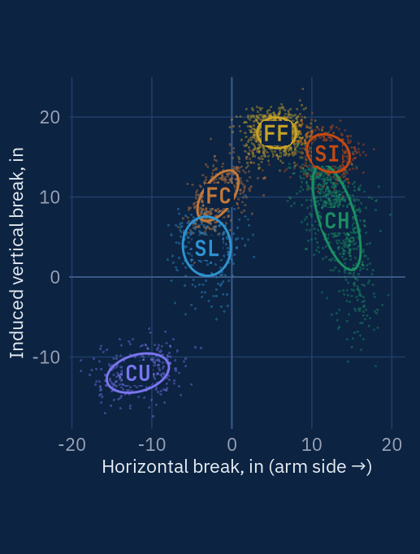

n = 3,028 pitches. Ellipses hold about 68% of each type; codes sit at the averages.

### Location by count

He throws 61% of pitches in the zone when behind and 42% when ahead.

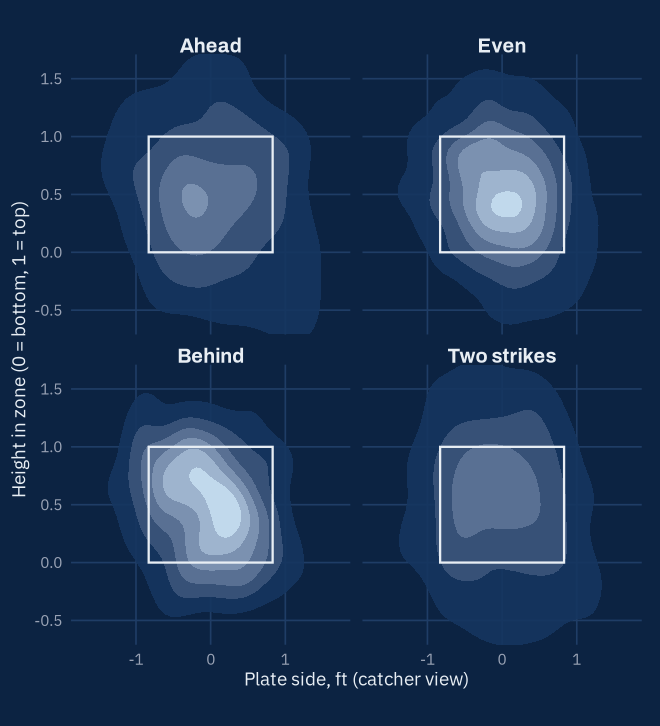

n = 3,028. Ahead 405 · even 1114 · behind 590 · two strikes 919 pitches. Box = rule-book zone.

### Put-away

The CH is 33% of two-strike pitches vs 25% overall.

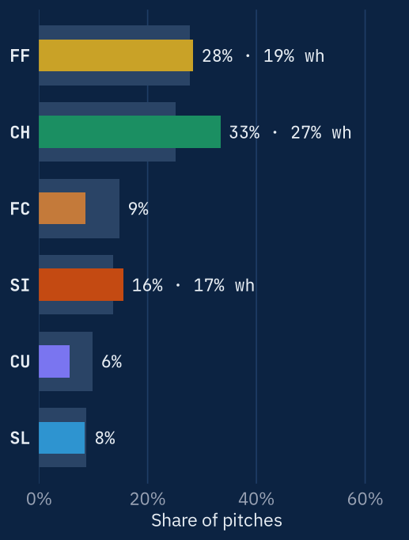

Two-strike n: CH 307, FF 261, SI 143, FC 79, SL 77, CU 52. Grey bars = overall usage; wh = whiffs per swing (shown with 50+ swings).

### Arsenal

| Pitch | # | Use | Velo | IVB | HB | VAA | Whiff | Chase | xwOBAcon | xRV/100 | Stuff+ |
| --- | --- | --- | --- | --- | --- | --- | --- | --- | --- | --- | --- |
| 4-Seam (FF) | 840 | 28% | 93.2 | 18.0 | +5.6 | -5.3 | 20% | 31% | .389 | -0.05 | 97 |
| Changeup (CH) | 762 | 25% | 80.6 | 7.1 | +13.2 | -8.4 | 28% | 38% | .271 | +1.47 | 114 |
| Cutter (FC) | 449 | 15% | 89.5 | 10.2 | -1.6 | -6.6 | 14% | 25% | .365 | +0.63 | 100 |
| Sinker (SI) | 413 | 14% | 93.2 | 15.5 | +11.9 | -5.9 | 13% | 25% | .404 | -0.80 | 86 |
| Curveball (CU) | 301 | 10% | 75.9 | -12.0 | -11.7 | -10.6 | 26% | 21% | .369 | -0.76 | 93 |
| Slider (SL) | 263 | 9% | 85.0 | 3.6 | -3.1 | -8.3 | 30% | 28% | .349 | -0.27 | 100 |

IVB / HB in inches (HB + = arm side). VAA in degrees at the front of the plate. xRV/100 = expected run value per 100 pitches, pitcher’s view, shrunk with a 250-pitch prior. Stuff+ = this project’s shape-only model (100 = MLB average, 10 = 1 SD).

### Vs. batter hand

| Pitch | LHH # | Use | Whiff | xwOBAcon | RHH # | Use | Whiff | xwOBAcon |
| --- | --- | --- | --- | --- | --- | --- | --- | --- |
| FF | 562 | 31% | 21% | .358 | 278 | 23% | 20% | .286 |
| CH | 594 | 33% | 29% | .225 | 168 | 14% | 24% | .224 |
| FC | 280 | 16% | 14% | .282 | 169 | 14% | 15% | .465 |
| SI | 134 | 7% | 16% | .289 | 279 | 23% | 11% | .435 |
| CU | 187 | 10% | 24% | .360 | 114 | 9% | – | .278 |
| SL | 37 | 2% | – | .305 | 226 | 18% | 32% | .299 |

Use = share of pitches to that side. Whiff = whiffs per swing, shown with 50+ swings.